# RepDataAssignment1-PA

Peter Anger

4/20/2018

This markdown file was produced for the first assignment in the Reproducible Research course.

##### Load the the activity data

- read in the csv file

```r
act<-read.csv("activity.csv",colClasses="character")
head(act)
```

```
##   steps       date interval
## 1  <NA> 2012-10-01        0
## 2  <NA> 2012-10-01        5
## 3  <NA> 2012-10-01       10
## 4  <NA> 2012-10-01       15
## 5  <NA> 2012-10-01       20
## 6  <NA> 2012-10-01       25
```

- set appropriate classes for ech column of data

```r
act[,1] <- as.numeric(act[,1])
act[,3] <- as.numeric(act[,3])
str(act)
```

```
## 'data.frame':    17568 obs. of  3 variables:
##  $ steps   : num  NA NA NA NA NA NA NA NA NA NA ...
##  $ date    : chr  "2012-10-01" "2012-10-01" "2012-10-01" "2012-10-01" ...
##  $ interval: num  0 5 10 15 20 25 30 35 40 45 ...
```

##### Look at daily values:

- make a clean copy of the data (removing rows with NA data)

```r
cleanAct <- na.omit(act)
```

- compute the total steps per day

```r
totalStepsDay <- tapply(cleanAct$steps,cleanAct$date,sum)
head(totalStepsDay)
```

```
## 2012-10-02 2012-10-03 2012-10-04 2012-10-05 2012-10-06 2012-10-07
##        126      11352      12116      13294      15420      11015
```

- generate a histogram of total steps per day

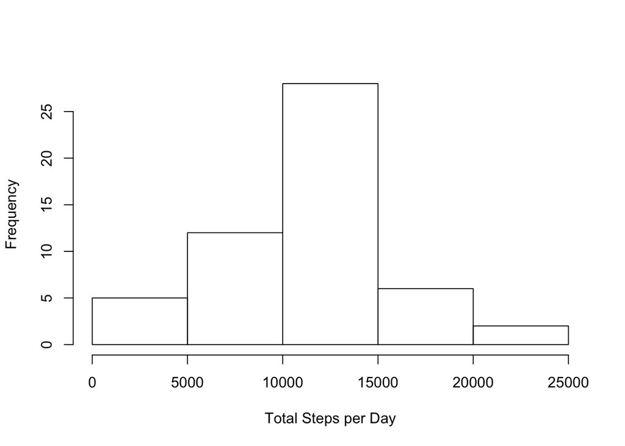

- identify the mean and median total steps per day

```r
mean(totalStepsDay)
```

```
## [1] 10766.19
```

```r
median(totalStepsDay)
```

```
## [1] 10765
```

##### Look at the daily activity pattern:

- compute the number of steps per interval averaged across days

```r
meanStepsInterval <-tapply(cleanAct$steps,cleanAct$interval,mean)
meanStepsInterval<-data.frame(interval=as.numeric(rownames(meanStepsInterval)),steps=meanStepsInterval)
head(meanStepsInterval)
```

```
##    interval     steps
## 0         0 1.7169811
## 5         5 0.3396226
## 10       10 0.1320755
## 15       15 0.1509434
## 20       20 0.0754717
## 25       25 2.0943396
```

- create a time series plot of the steps per interval

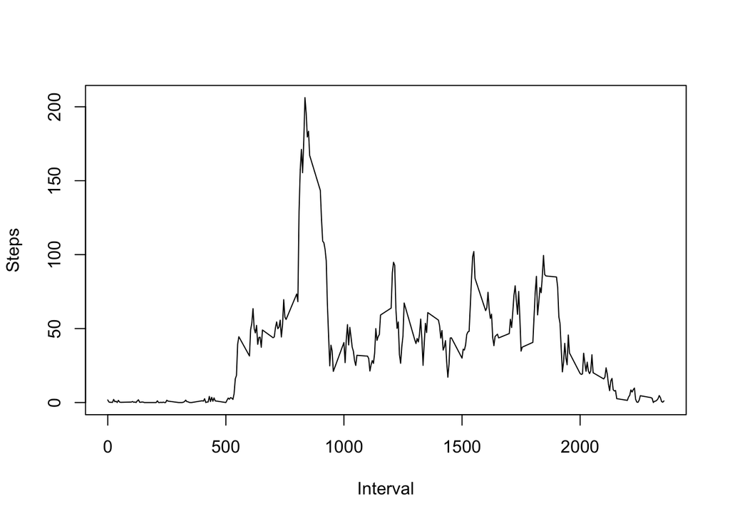

- identify the interval with the highest average step count

```r
meanStepsInterval$interval[which.max(meanStepsInterval$steps)]
```

```
## [1] 835
```

- and the corresponding step count

```r
max(meanStepsInterval$steps)
```

```
## [1] 206.1698
```

##### Fill in mising values:

- identify the number of rows with NA data

```r
nrow(act)-nrow(cleanAct)
```

```
## [1] 2304
```

- create a copy of the dataset

```r
fixedAct<-act
```

- replace NA values with the mean number of steps for the given interval (averaged across all days)

```r
for (row in 1:nrow(fixedAct)) {
    if (is.na(fixedAct$steps[row])) {
        fixedAct$steps[row] <- round(meanStepsInterval$steps[(as.character(fixedAct$interval[row]))])
    }
}
```

##### Reanalyze the “fixed” daily data

- compute total steps per day

```r
totalStepsDay2 <- tapply(fixedAct$steps,fixedAct$date,sum)
head(totalStepsDay2)
```

```
## 2012-10-01 2012-10-02 2012-10-03 2012-10-04 2012-10-05 2012-10-06
##      10762        126      11352      12116      13294      15420
```

- generate a histogram of daily steps

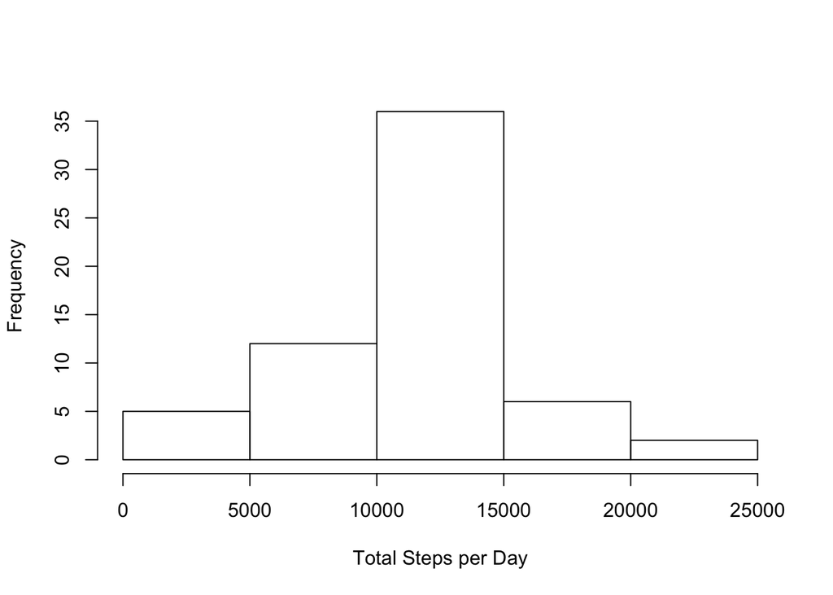

- identify the mean daily steps

```r
mean(totalStepsDay2)
```

```
## [1] 10765.64
```

- identify the median daily steps

```r
median(totalStepsDay2)
```

```
## [1] 10762
```

- compare to cleaned data

```r
mean(totalStepsDay2) / mean(totalStepsDay)
```

```
## [1] 0.999949
```

```r
median(totalStepsDay2) / median(totalStepsDay)
```

```
## [1] 0.9997213
```

##### Reanalyze the “fixed” interval data

- compute count of fixed steps per interval averaged across all days

```r
meanStepsInterval2 <-round(tapply(fixedAct$steps,fixedAct$interval,mean))
meanStepsInterval2<-data.frame(interval=as.numeric(rownames(meanStepsInterval2)),steps=meanStepsInterval2)
head(meanStepsInterval2)
```

```
##    interval steps
## 0         0     2
## 5         5     0
## 10       10     0
## 15       15     0
## 20       20     0
## 25       25     2
```

- create a time series plot of the steps per interval

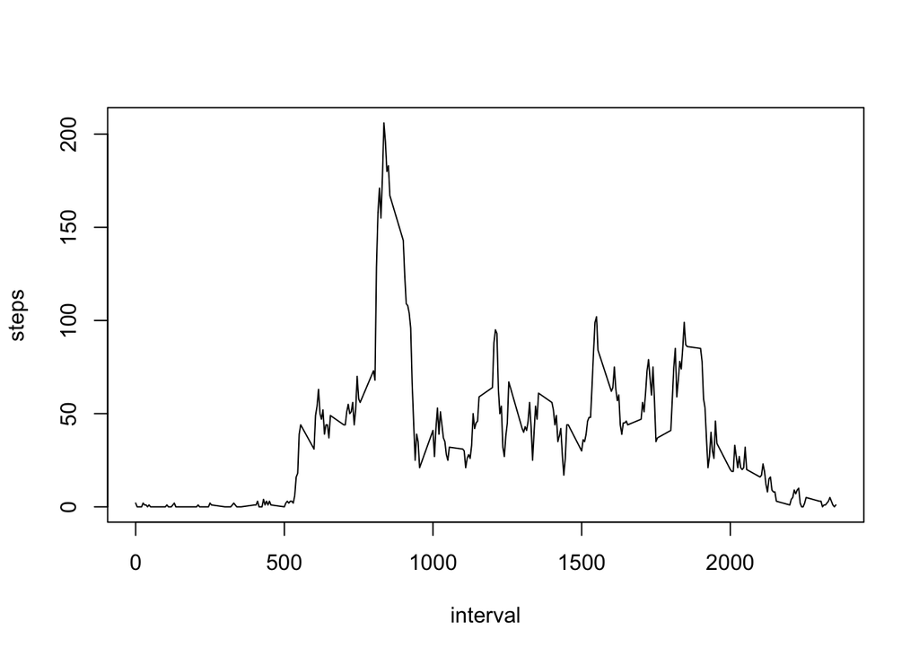

- identify the interval with the highest average step count

```r
meanStepsInterval2$interval[which.max(meanStepsInterval2$steps)]
```

```
## [1] 835
```

```r
max(meanStepsInterval2$steps)
```

```
## [1] 206
```

- compare to cleaned data

```r
meanStepsInterval2$interval[which.max(meanStepsInterval2$steps)] / meanStepsInterval$interval[which.max(meanStepsInterval$steps)]
```

```
## [1] 1
```

```r
max(meanStepsInterval2$steps) / max(meanStepsInterval$steps)
```

```
## [1] 0.9991764
```

##### Organize data by weekday Vs weekend

- add a factor indicating whether a given date is a weekday or a weekend

```r
type<-as.character()
days <- c("Monday","Tuesday","Wednesday","Thursday","Friday","Saturday","Sunday")
for (i in 1:5) type[days[i]] <- "weekday"
for (i in 6:7) type[days[i]] <- "weekend"
fixedAct$dayType <- type[weekdays(as.Date(fixedAct$date))]
fixedAct$dayType <- as.factor(fixedAct$dayType)
```

- create subsets of the data for weekdays vs weekends

```r
fixedActWD<-subset(fixedAct,as.character(fixedAct$dayType)=="weekday")
meanStepsIntervalWD <-round(tapply(fixedActWD$steps,fixedActWD$interval,mean))
meanStepsIntervalWD<-data.frame(interval=as.numeric(as.character(rownames(meanStepsIntervalWD))),steps=meanStepsIntervalWD)
fixedActWE<-subset(fixedAct,as.character(fixedAct$dayType)=="weekend")
meanStepsIntervalWE <-round(tapply(fixedActWE$steps,fixedActWE$interval,mean))
meanStepsIntervalWE<-data.frame(interval=as.numeric(as.character(rownames(meanStepsIntervalWE))),steps=meanStepsIntervalWE)
```

##### Compare weekday to weekend steps

-Generate a time series panel plot per the read.me example that compares the mean steps/interval for weekdays and weekends.

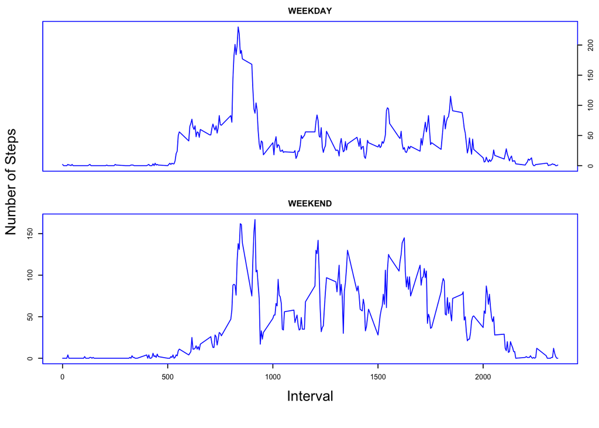